# Classification on Weight Lifting Exercises Data

## Synopsis

In this report, we will try to build a classifier and try to estimate its out-of-sample performance. The classifier is built on [Weight Lifting Exercises Data](http://groupware.les.inf.puc-rio.br/har), in which 6 participants have been performed dumbbell exercises in 5 different ways, i.e. correctly (A) and incorrectly (B, C, D, E).

The classifier is built using [Random Forest](http://en.wikipedia.org/wiki/Random_forest) algorithm. The original dataset is split at the outset of the analysis, into the training set (80%) and validation set (20%). Only the training set is used in a repeated (5 times) 10-fold cross validation to train a model, estimating its out-of-sample error. Finally, the model performance is confirmed on the separate validation set. From the result of the validation set prediction, we estimate that the out-of-sample accuracy of the model is around 95%.

## Details

### Getting / Loading Data

The data is downloaded from the course project page, and is loaded into the workspace with standard `csv.read()` function.

```r
training_csv_url = 'https://d396qusza40orc.cloudfront.net/predmachlearn/pml-training.csv'
training_csv = basename(training_csv_url)

if (!file.exists(training_csv)) {
  download.file(training_csv_url, destfile=training_csv, method='curl')
}
```

```r
training <- read.csv(training_csv, na.strings=c('""', 'NA', '#DIV/0!'))
dim(training)
```

```
## [1] 19622   160
```

From the result of the `str()` function, we can see the following things:

- outcome is in the `classe` column
- some columns are not a part of sensor data (e.g. timestamps, participants’ name, etc.)
- a lot of data point is missing (`NA`)

```r
str(training)  # output is omitted to save the space.
```

To address first two problems, only the sensor data is extracted from the training data, and they are converted into a numeric matrix.

```r
training_matrix_all <- data.matrix(
  subset(training,
         select=-c(X,
                   user_name,
                   raw_timestamp_part_1,
                   raw_timestamp_part_2,
                   cvtd_timestamp,
                   new_window,
                   num_window,
                   classe)))
```

### Splitting the Training Data

To build a model, we will use cross validation method, which is built into the `caret::train()` function. The function takes a set of training data, and performs cross validation tests internally to select an optimal model. After getting a model, we will need to confirm its performance by a validation dataset, which should not be overlapped with the training dataset.

So before the further processing, we split the original dataset into two parts, training dataset (`training_matrix`) and validation dataset (`validation_matrix`). This is done by `caret::createDataPartition()` as shown below.

We selected a commonly used number of 20%, to set apart the validation data.

```r
set.seed(18181)
in_train <- createDataPartition(y=training$classe, p=0.8, list=F)
training_matrix <- training_matrix_all[in_train,]
validation_matrix <- training_matrix_all[-in_train, ]
dim(training_matrix)
```

```
## [1] 15699   152
```

```r
dim(validation_matrix)
```

```
## [1] 3923  152
```

### Filtering Columns

Although the dataset has a fairly large number of columns, they are not necessarily informative to predict the outcome. Having too many variables is also negative for the model training time. So we try to filter out valueless variables, by removing columns filled mostly with NAs, finding near zero variance variables, and highly correlated variables. Also, data normalization and imputation of missing values is done along the way. All the transformation is done by functionality of `caret` package. See [the document about pre-processing](http://caret.r-forge.r-project.org/preprocess.html) for the details.

#### Removing Columns Filled Mostly with NAs

Columns in which almost all (90% or more) data is missing is removed.

```r
table(apply(training_matrix, 2, function(x) sum(is.na(x))))
```

```
##
##     0 15356 15357 15358 15360 15361 15363 15364 15365 15386 15420 15421
##    52    67     1     1     1     4     1     4     2     2     1     1
## 15423 15426 15427 15699
##     2     1     6     6
```

```r
na_cols = apply(training_matrix, 2, function(x) sum(is.na(x))) > (0.9 * nrow(training_matrix))
training_matrix_rmnacol <- training_matrix[,!na_cols]
dim(training_matrix_rmnacol)
```

```
## [1] 15699    52
```

#### Removing Near Zero Variance Variables

Variables without much variance are removed here.

```r
nzv <- nearZeroVar(training_matrix_rmnacol, saveMetrics = TRUE)
training_matrix_filtered <- training_matrix_rmnacol[,!nzv$nzv]
dim(training_matrix_filtered)
```

```
## [1] 15699    52
```

In this case, no such columns are found.

#### Normalizing Variables and Imputing Missing Values

Then, imputation of remaining missing data and centering/scaling is done. In the training set, in this case, there is no missing data, but the future data may have NAs, so the process is needed.

```r
sum(is.na(training_matrix_filtered))
```

```
## [1] 0
```

```r
impute_model <- preProcess(training_matrix_filtered, method="medianImpute")
tmp <- predict(impute_model, training_matrix_filtered)
scale_model <- preProcess(tmp, method=c('center', 'scale'))
training_matrix_transformed <- predict(scale_model, tmp)
rm('tmp')
sum(is.na(training_matrix_transformed))
```

```
## [1] 0
```

#### Removing Highly Correlated Variables

Columns with high correlation (90% or more) are removed.

```r
cor_training <- cor(training_matrix_transformed)
summary(cor_training[upper.tri(cor_training)])
```

```
##    Min. 1st Qu.  Median    Mean 3rd Qu.    Max.
## -0.9920 -0.1090  0.0015  0.0018  0.0920  0.9810
```

```r
highly_correlated = findCorrelation(cor_training)
training_matrix_nocor <- training_matrix_transformed[, -highly_correlated]
dim(training_matrix_nocor)
```

```
## [1] 15699    45
```

### Dimensionality Reduction by PCA

Even after removing variables with near zero variance and/or high correlation, there are 45 columns in the dataset. It is still a high number, so we try [PCA](http://en.wikipedia.org/wiki/Principal_component_analysis) for further reduction. In this instance, 80% of the variance is retained.

```r
pca_model <- preProcess(training_matrix_nocor, method="pca", thresh=0.8)
training_matrix_pca <- predict(pca_model, training_matrix_nocor)
dim(training_matrix_pca)
```

```
## [1] 15699    13
```

By using PCA, interpretation of the predictors in the model would become difficult, and it might somewhat lower the prediction performance of the resulting model, but I preferred the compact model here. As a result, the number of the columns are reduced drastically, from 45 to 13.

### Training Model

Then, finally, a model is trained with the principal components as its predictors. [Random Forest](http://en.wikipedia.org/wiki/Random_forest) is chosen as an algorithm, and a repeated (5 times) 10-fold cross validation is used to estimate a out-of-sample error and to select an optimal parameter set.

```r
training_df <- cbind(data.frame(training_matrix_pca), classe=training[in_train, ]$classe)
control <- trainControl(method="repeatedcv",
                        number=10, repeats=5)
rf_model <- train(classe ~ ., data=training_df,
                  method='rf', trControl=control)
rf_model
```

```
## Random Forest
##
## 15699 samples
##    13 predictors
##     5 classes: 'A', 'B', 'C', 'D', 'E'
##
## No pre-processing
## Resampling: Cross-Validated (10 fold, repeated 5 times)
##
## Summary of sample sizes: 14131, 14129, 14129, 14129, 14129, 14129, ...
##
## Resampling results across tuning parameters:
##
##   mtry  Accuracy  Kappa  Accuracy SD  Kappa SD
##   2     1         1      0.004        0.006
##   7     1         0.9    0.006        0.007
##   10    0.9       0.9    0.006        0.008
##
## Accuracy was used to select the optimal model using  the largest value.
## The final value used for the model was mtry = 2.
```

```r
rf_model$finalModel
```

```
##
## Call:
##  randomForest(x = x, y = y, mtry = param$mtry)
##                Type of random forest: classification
##                      Number of trees: 500
## No. of variables tried at each split: 2
##
##         OOB estimate of  error rate: 3.55%
## Confusion matrix:
##      A    B    C    D    E class.error
## A 4371   32   45   14    2     0.02083
## B   77 2874   63   15    9     0.05398
## C   23   38 2643   29    5     0.03470
## D   19   11  104 2433    6     0.05441
## E    6   18   23   19 2820     0.02287
```

To make a prediction on new data, it is necessary to transform them by using the same method in which the training set is done.

```r
validation_matrix_rmnacol <- validation_matrix[,!na_cols]
validation_matrix_transformed <-
  predict(scale_model,
          predict(impute_model,
                  validation_matrix_rmnacol[, !nzv$nzv]))
validation_matrix_pca <- predict(pca_model,
                                 validation_matrix_transformed[, -highly_correlated])

validation_predict <- predict(rf_model, validation_matrix_pca)
validation_result <- confusionMatrix(validation_predict, training[-in_train,]$classe)
validation_result
```

```
## Confusion Matrix and Statistics
##
##           Reference
## Prediction    A    B    C    D    E
##          A 1097   20    5    6    2
##          B    5  725    8    3    2
##          C    8   12  664   28    8
##          D    4    1    6  606    3
##          E    2    1    1    0  706
##
## Overall Statistics
##
##                Accuracy : 0.968
##                  95% CI : (0.962, 0.973)
##     No Information Rate : 0.284
##     P-Value [Acc > NIR] : < 2e-16
##
##                   Kappa : 0.96
##  Mcnemar's Test P-Value : 0.00013
##
## Statistics by Class:
##
##                      Class: A Class: B Class: C Class: D Class: E
## Sensitivity             0.983    0.955    0.971    0.942    0.979
## Specificity             0.988    0.994    0.983    0.996    0.999
## Pos Pred Value          0.971    0.976    0.922    0.977    0.994
## Neg Pred Value          0.993    0.989    0.994    0.989    0.995
## Prevalence              0.284    0.193    0.174    0.164    0.184
## Detection Rate          0.280    0.185    0.169    0.154    0.180
## Detection Prevalence    0.288    0.189    0.184    0.158    0.181
## Balanced Accuracy       0.986    0.975    0.977    0.969    0.989
```

As shown in the result, accuracy of the classification on the validation set is 96.81%. This is roughly the same level as the result of the cross validation process (done in the `caret::train()` function).

## Appendix

### Appendix A. Normalized Confusion Matrix of the Final Model (on Validation Set)

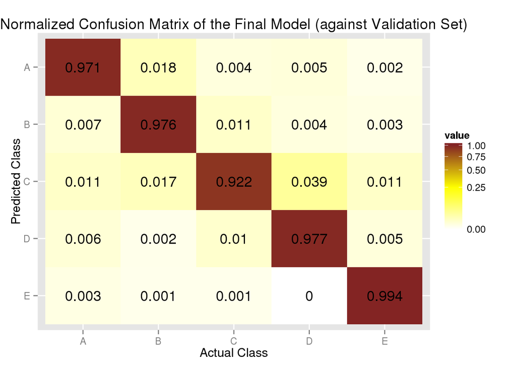

```r
library(reshape2)
library(scales)
validation_result_norm <- apply(validation_result$table, 1,
                                function(x) x / sum(x))
confusion_df <- melt(validation_result_norm)
confusion_df$Prediction <- with(confusion_df,
                                factor(Prediction,
                                       levels=rev(levels(Prediction))))
colnames(confusion_df) <- c('Actual', 'Predicted', 'value')

g <- ggplot(confusion_df, aes(x=Actual, y=Predicted)) +
  geom_tile(aes(fill=value)) +
  scale_fill_gradient2(limits=c(0,1),
                       high=muted("red"), mid="yellow", low="white",
                       midpoint=0.5, trans="sqrt") +
  geom_text(aes(label=round(value, 3))) +
  xlab("Actual Class") +
  ylab("Predicted Class") +
  ggtitle("Normalized Confusion Matrix of the Final Model (against Validation Set)")
print(g)
```

### Appendix B. Predicting Course Test Data (code is not evaluated)

```r
testing_csv_url = 'https://d396qusza40orc.cloudfront.net/predmachlearn/pml-testing.csv'
testing_csv = basename(testing_csv_url)

if (!file.exists(testing_csv)) {
  download.file(testing_csv_url, destfile=testing_csv, method='curl')
}

testing <- read.csv(testing_csv, na.strings=c('""', 'NA', '#DIV/0!'))
dim(testing)

testing_matrix <- data.matrix(
  subset(testing,
         select=-c(X,
                   user_name,
                   raw_timestamp_part_1,
                   raw_timestamp_part_2,
                   cvtd_timestamp,
                   new_window,
                   num_window,
                   problem_id)))

testing_matrix_rmnacol <- testing_matrix[, !na_cols]
testing_matrix_transformed <-
  predict(scale_model,
          predict(impute_model,
                  testing_matrix_rmnacol[, !nzv$nzv]))
testing_matrix_pca <- predict(pca_model,
                              testing_matrix_transformed[, -highly_correlated])

testing_predict <- predict(rf_model, testing_matrix_pca)
```